# Exploratory Data Analysis and Visualization

Lecture 03

January 28, 2026

# Review

## Probability Fundamentals

- Bayesian vs. Frequentist Interpretations
- Distributions reflect assumptions on probability of data.
- Normal distributions: “least informative” distribution for a given mean/variance.
- Fit distributions by maximizing likelihood.
- Communicating uncertainty: confidence vs. predictive intervals.

# Exploratory Data Analysis

## You Can Always Fit Models…

But not all models **are theoretically justifiable**.

[figure not shown]

Ian Malcolm meme

## Some Implications of Mis-Specification

- Biased estimates (expected value from the model does not match “true” expected value);
- Incorrect inferences or inappropriate understandings of relationships/causality.
- Over/under-confident risk assessments.

## Data Generation Approximates Reality

[figure not shown]

Estimand Estimator Cake

[figure not shown]

Estimand Estimator Cake

[figure not shown]

Estimate Cake

Source: Richard McElreath

## How Do We Choose What To Model?

[figure not shown]

XKCD 2620

Source: [XKCD 2620](https://xkcd.com/2620/)

## How Do We Choose What To Model?

Developing suitable models often starts with both **exploratory data analysis (EDA)** and **theoretical reasoning**.

1. **EDA**: examining patterns/relationships with visual (plots, clustering) or quantitative (correlations).
2. **Theory**: Avoids “data dredging” or “mining,” which can find spurious correlations or patterns which are misleading without broader context about data-generating mechanisms.

## Exploratory Data Analysis

- Will see many examples of this throughout the semester.
- Try to impose as few assumptions as possible.
- Goal of exploratory analysis is to **get a high-level view of the data** and **formulate hypotheses/check if data is fit for purpose**.

## EDA Questions

EDA is about generating questions and identifying if the data quality is sufficient to address them.

Common questions to guide EDA:

1. **What type of variability occurs within my variables?**
2. **What type of covariation occurs between my variables?**

## Common EDA Questions

- What is the range of the data? What are “typical” values?
- What values are rare? Do they make sense?
- Are there missing data or strange outliers? What might explain them?
- Is a particular relationship or distribution supported by the data?

## Common EDA Approaches

- Data summaries (quantiles, mean/median, max/min, etc.)
- Correlations
- **Plot data** (from multiple perspectives)
- Clustering (do you need multiple models?)

## Example: NY Air Quality Dataset

```julia
aq = DataFrame(CSV.File("data/airquality/airquality.csv"))
rename!(aq, :"Solar.R" => :Solar) # rename solar radiation column to get rid of period
aq[1:5, :]
```

5×7 DataFrame

| Row | rownames Int64 | Ozone Int64? | Solar Int64? | Wind Float64 | Temp Int64 | Month Int64 | Day Int64 |
| --- | --- | --- | --- | --- | --- | --- | --- |
| 1 | 1 | 41 | 190 | 7.4 | 67 | 5 | 1 |
| 2 | 2 | 36 | 118 | 8.0 | 72 | 5 | 2 |
| 3 | 3 | 12 | 149 | 12.6 | 74 | 5 | 3 |
| 4 | 4 | 18 | 313 | 11.5 | 62 | 5 | 4 |
| 5 | 5 | missing | missing | 14.3 | 56 | 5 | 5 |

## Quantitative EDA: Summaries

```julia
aq_stack = stack(aq, 2:5)
aq_gp = @groupby(aq_stack, :variable)
@combine(aq_gp, $AsTable = (
        min=minimum(skipmissing(:value)),
        median=median(skipmissing(:value)),
        mean=mean(skipmissing(:value)),
        max=maximum(skipmissing(:value)),
        missings=sum(ismissing.(:value))
    )
)
```

4×6 DataFrame

| Row | variable String | min Float64 | median Float64 | mean Float64 | max Float64 | missings Int64 |
| --- | --- | --- | --- | --- | --- | --- |
| 1 | Ozone | 1.0 | 31.5 | 42.1293 | 168.0 | 37 |
| 2 | Solar | 7.0 | 205.0 | 185.932 | 334.0 | 7 |
| 3 | Wind | 1.7 | 9.7 | 9.95752 | 20.7 | 0 |
| 4 | Temp | 56.0 | 79.0 | 77.8824 | 97.0 | 0 |

## Quantitative EDA: Correlations

```julia
aq_cor = cor(Matrix(dropmissing(aq[:, 2:5])))
DataFrame(aq_cor, names(aq[:, 2:5]))
```

4×4 DataFrame

| Row | Ozone Float64 | Solar Float64 | Wind Float64 | Temp Float64 |
| --- | --- | --- | --- | --- |
| 1 | 1.0 | 0.348342 | -0.612497 | 0.698541 |
| 2 | 0.348342 | 1.0 | -0.127183 | 0.294088 |
| 3 | -0.612497 | -0.127183 | 1.0 | -0.49719 |
| 4 | 0.698541 | 0.294088 | -0.49719 | 1.0 |

# Visual EDA

## Anscombe’s Quartet

Four datasets, all with the same means, variances, correlations, and regression lines.

Shows the importance of visualization!

[figure not shown]

Anscombe’s Quartet

Source: [Wikipedia](https://en.wikipedia.org/wiki/Anscombe%27s_quartet)

## Visualizations for EDA

- Often useful to start with **scatterplots**: one variable (typically independent) on the $x$-axis, another (typically dependent) on the $y$-axis.
- Time series: **time always goes on the $x$-axis**.
- Boxplots for comparison quantiles/ranges of variables or groups of data.
- Q-Q Plots to look for mismatches between distributions and data.

## Boxplots vs Histograms

**Boxplots**: Show quantiles (usually median + 1.5 $\times$ IQR)

**Histogram**: See distribution of data.

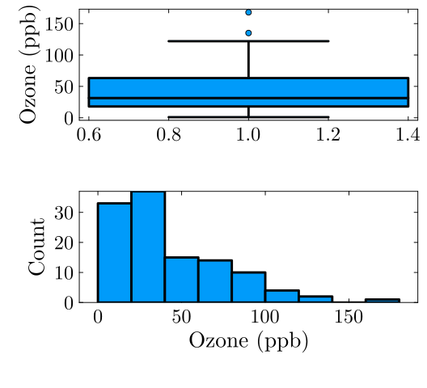

Figure 1: Paired plots of air quality dataset

```julia
p1 = boxplot(skipmissing(aq[!, :Ozone]), ylabel="Ozone (ppb)")

p2 = histogram(skipmissing(aq[!, :Ozone]), xlabel="Ozone (ppb)", ylabel="Count")

p = plot(p1, p2, layout=(2, 1), size=(550, 500))
```

## Scatterplots

```julia
# this uses the dataframe plotting syntax from StatsPlots.jl
p1 = @df aq scatter(:Ozone, :Solar, markersize=5, color=:blue, xlabel="Ozone (ppb)", ylabel="Solar Radiation (lang)", leftmargin=10mm)
p2 = @df aq scatter(:Ozone, :Wind, markersize=5, color=:blue, xlabel="Ozone (ppb)", ylabel="Wind Speed (mph)", leftmargin=10mm)
p3 = @df aq scatter(:Ozone, :Temp, markersize=5, color=:blue, xlabel="Ozone (ppb)", ylabel="Max Temperature (°F) ", leftmargin=10mm)

p = plot(p1, p2, p3, layout=(1, 3), size=(1100, 400))
```

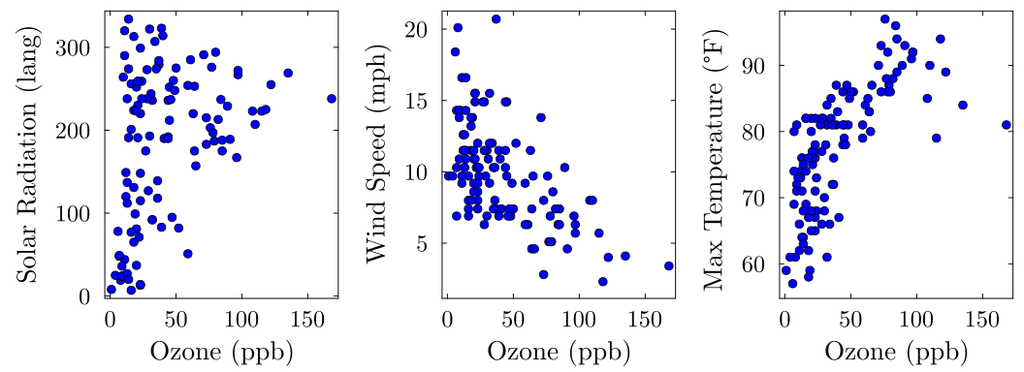

Figure 2: Paired plots of air quality dataset

## Fit Distributions and Compare to Histograms

If we have a candidate distribution, we can try to fit it to the data and visually compare to a histogram.

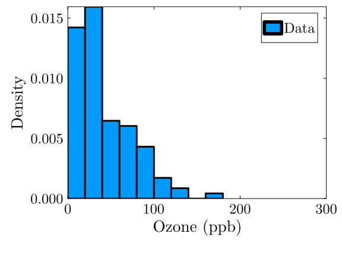

Figure 3: Histogram of Ozone measurements in Air Quality Dataset

```julia
# normalize=:pdf turns the y-axis from a raw count to a density to make more comparable with a PDF
pozone = histogram(skipmissing(aq[!, :Ozone]), xlabel="Ozone (ppb)", ylabel="Density", normalize=:pdf, label="Data", size=(600, 450), rightmargin=5mm)
xlims!(pozone, (0, 300))
```

## Fit Distributions and Compare to Histograms

Here we might try a Log-Normal distribution.

```julia
d = fit(LogNormal, collect(skipmissing(aq[!, :Ozone])))
```

```
Distributions.LogNormal{Float64}(μ=3.418515100812007, σ=0.8654745374223664)
```

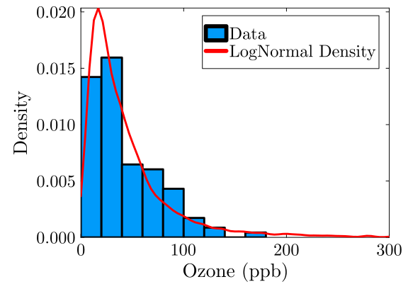

Figure 4: Histogram of Ozone measurements in Air Quality Dataset

```julia
ln_samps = rand(d, 5_000)
density!(pozone, ln_samps, linewidth=3, color=:red, label="LogNormal Density")
```

## Q-Q Plots

One exploratory method to see if your data is reasonably described by a theoretical distribution is a **Q-Q plot**.

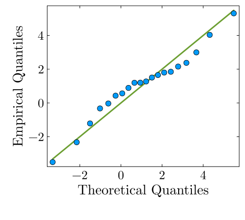

Figure 5

```julia
samps = rand(Normal(0, 3), 20)
qqplot(Normal, samps, linewidth=3, markersize=6)
xlabel!("Theoretical Quantiles")
ylabel!("Empirical Quantiles")
plot!(size=(500, 450))
```

## Q-Q Plots: Data Overdispersed

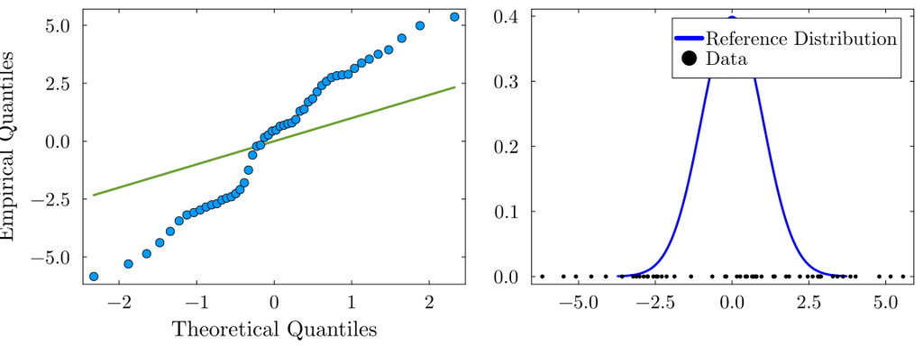

Figure 6: Diagnosing Problems With Q-Q Plots

## Q-Q Plots: Data Underdispersed

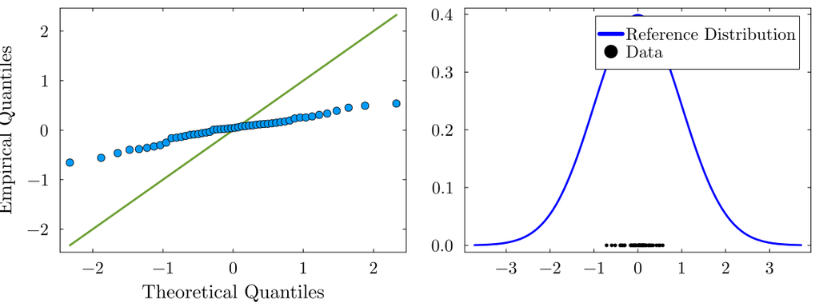

Figure 7: Diagnosing Problems With Q-Q Plots

## Q-Q Plots: Data Skewed

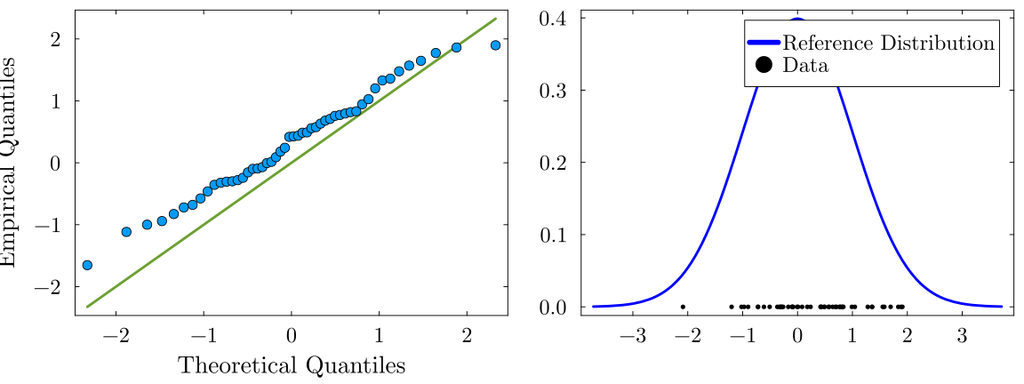

Figure 8: Diagnosing Problems With Q-Q Plots

## Q-Q Plots: Data Biased

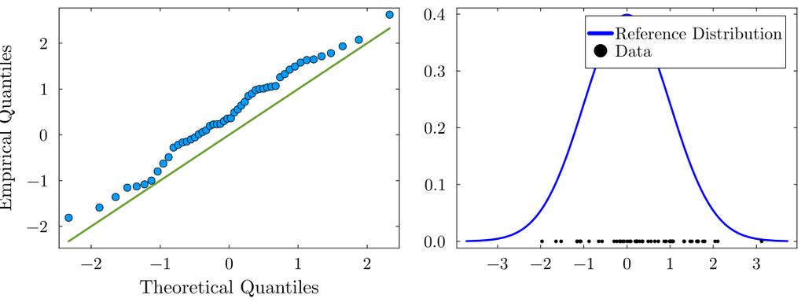

Figure 9: Diagnosing Problems With Q-Q Plots

## Q-Q Plots With Fitted Distributions

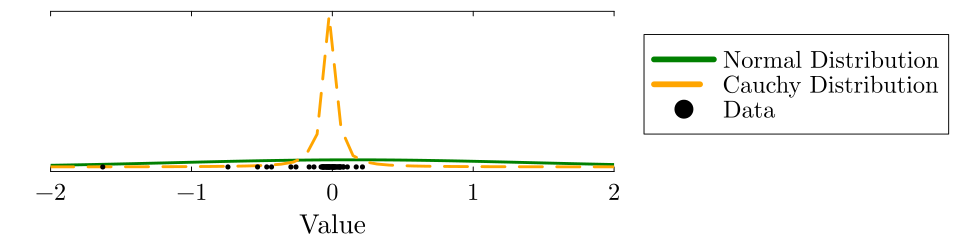

(a) Normal vs Cauchy Distribution

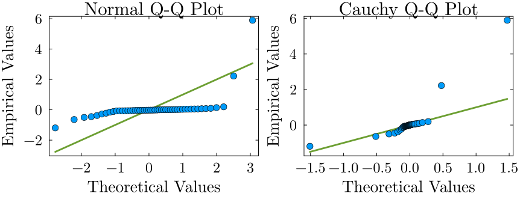

(b) Q-Q Plot

Figure 10: Q-Q Plot for Cauchy Data and Normal Distribution

## Ozone Data: LogNormal Fit

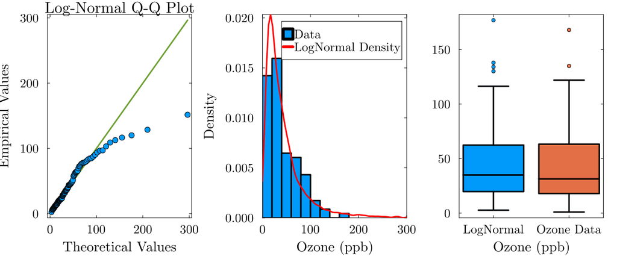

Figure 11: QQ Plot comparing ozone data with LogNormal distribution

```julia
p1 = qqplot(LogNormal, collect(skipmissing(aq[!, :Ozone])), linewidth=3, markersize=6, title="Log-Normal Q-Q Plot", leftmargin=5mm)
xlabel!(p1, "Theoretical Values")
ylabel!(p1, "Empirical Values")
plot!(pozone, xlims=(0, 300))
p3 = boxplot([ln_samps[1:116] collect(skipmissing(aq[!, :Ozone]))], xlabel="Ozone (ppb)")
xticks!(p3, [1, 2], ["LogNormal", "Ozone Data"])
plot(p1, pozone, p3, layout=(1, 3), size=(1250, 525), rightmargin=5mm, leftmargin=5mm)
```

# Key Points

## EDA

- **EDA**: Understand structure of data while making as few assumptions as possible (e.g. look at the raw data, not “smoothed” versions).
- Need to be willing to ask many questions of your data: most won’t make sense once you look at the data.
- You might be asking the “right” questions but have the “wrong” data: be open-minded and rely on domain knowledge.

## Visual EDA

- Need to experiment with different visualizations.
- Think about whether you think the distribution of the data is meaningful at this stage.
- Can draw samples from a fitted distribution and compare (Q-Q plots, boxplots, histograms, etc).
- **Look at multiple plots: they each reveal different features!**

# Upcoming Schedule

## Next Classes

**Friday**: Data Visualization

**Next Week**: Linear Regression and Fitting Models

## Assessments

**Homework 1** Due Friday, 2/6.

**Exercises**: This week’s involves some simple computations.

**Reading**: Franconeri et al (2024): long review, recommend starting early!

# References